# TALLER: Tutorial R – Distribuciones muestrales e intervalos de confianza

Autores:

- Yesid Romario Gualdrón Hurtado, 2190052
- Daniel Alejandro Leon Ortiz, 2190064

## 1. Funciones en R

Para construir funciones en R es necesario seguir la siguiente estructura:

```r
nombre_de_funcion <- function(par1, par2, ...) {
  cuerpo
  return(resultado)
}
```

Dichas funciones se pueden usar digitando su nombre seguido de los parámetros entre paréntesis, son usadas para encapsular código que se usará constantemente y a pesar de no retornar más de un valor, es posible crear una lista de diferentes salidas y retornarla, como se mostrará a continuación en el caso de la función iqr(v), que recibe como entrada un vector de valores numéricos y dentro calcula el primer y tercer cuartil (0.25 y 0.75) haciendo uso de la función predefinida de R, quantile, la cual recibe el vector, los valores de los cuantiles requeridos y se setea el parámetro names en falso para que solo se retorne el valor y no su porcentaje (por ejemplo, 25% y 75%). Luego se guardan los valores que se quieren retornar en una lista (usando list) haciendo una asignación de clave-valor que finalmente se retornará.

```r
values = c(7,5,9,2,1,8,3,4,6,10)
iqr <- function(v) {
  q1 = quantile(v,1/4,names = FALSE)
  q3 = quantile(v,3/4,names = FALSE)
  iqr_list=list("q1"=q1,"q3"=q3,"ext"=q3-q1)
  return (iqr_list);
}
iqr(values)
```

```
$q1
[1] 3.25

$q3
[1] 7.75

$ext
[1] 4.5
```

## 2. Distribuciones de probabilidad en R

### Describir la función de densidad de probabilidad, función de distribución acumulada y función cuantil

- **Funciones de densidad de probabilidad:** Las funciones de densidad de probabilidad describen la probabilidad de observar cierto valor dentro de una muestra dada. Estas funciones se dividen en distribuciones discretas y continuas; la primera solo toma valores positivos en un conjunto de posibles valores, mientras que la segunda acepta valores tanto positivos como negativos.
- **Función de distribución acumulada:** La función de distribución acumulada describe la probabilidad de que una variable dentro de una muestra obtenga un valor n.
- **Función cuantil de la distribución:** Se le conoce como la función inversa de la función de distribución acumulada, debido a que indica el valor de la variable aleatoria para el cual la probabilidad de que esa variable aleatoria sea menor o igual a dicho valor sea la probabilidad dada.

### ¿Qué funciones existen en R que permitan obtener valores asociadas a esas funciones?

Las funciones para la función de densidad, la función acumulativa, la función cuantil y la creación de valores aleatorios que sigan cierta distribución, deben aplicarse sobre una distribución x, siendo **d**x, **p**x, **q**x y **r**x, respectivamente.

Estas distribuciones pueden ser:

#### Distribuciones Discretas:

**Binomial**: binom

**Poisson**: pois

**Geométrica**: geom

**Hipergeométrica**: hyper

**Binomial negativa**: nbinom

#### Distribuciones Continuas:

**Uniforme**: unif

**Normal**: norm

**t student**: t

**F Fisher**: F

**Chi-Cuadrado**: chisq

**Exponencial**: exp

**Gamma**: gamma

**Weibull**: weibull

**W de Wilcoxon**: wilcox

### Muestre estas funciones para 4 distribuciones de probabilidad diferentes (dos distribuciones de variables continuas y dos distribuciones de variables discretas). Use gráficas para visualizar dichas funciones.

#### Distribución Discreta

```r
x <- 1:80
par(mfrow = c(2, 3))
plot(dbinom(x, size = 80, prob = 0.2), type = "h", lwd = 2,
     main = "Densidad Binomial", ylab = "P(X = x)", xlab = "Número de éxitos", col = 'red')
plot(pbinom(x, size = 80, prob = 0.2), type = 'l',ylab = "P(X = x)",
     xlab = 'Número de éxitos', main = 'Acumulada Binomial', col = 'red')
```

```r
plot(qbinom(seq(0, 1, 0.001), size = 80, prob = 0.2), type='l',lwd = 2,
     main = 'Cuantil Binomial', ylab = 'Número de éxitos', xlab = 'P(X = x)', col = 'red', xaxt = "n")
axis(1, labels = seq(0, 1, 0.1), at = 0:10 * 100)
```

```r
lambda <- 5
plot(dpois(x, lambda), type = "h", lwd = 2,
     main = "Densidad Poisson",
     ylab = "P(X = x)", xlab = "Número de eventos", col = 'blue')
plot(ppois(x, lambda), type = "l", lwd = 2,
     main = "Acumulada Poisson",
     ylab = "P(X = x)", xlab = "Número de eventos", col = 'blue')
```

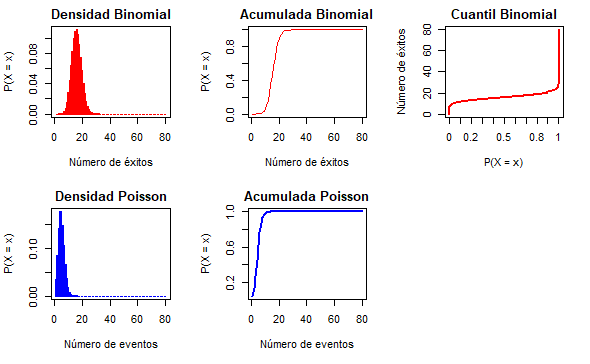

```r
plot(qpois(seq(0, 1, 0.001), lambda), type = "l", lwd = 2,
     main = "Cuantil Poisson",
     ylab = "P(X = x)", xlab = "Número de eventos", col = 'blue', xaxt = "n")
axis(1, labels = seq(0, 1, 0.1), at = 0:10 * 100)
```

[output not shown]

En las anteriores gráficas se logra observar la función de densidad, función acumulativa y función cuantil de 2 distribuciones discretas, siendo estas la **distribución binomial y la distribución Poisson.** Para estas distribuciones se inicia estableciendo un margen de valores en el eje x **(x <- 1:80)** y un lienzo para un total de 6 gráficas **(par(mfrow = c(2, 3)))**, posterior a esto, se grafican la función de densidad, función acumulativa y la función cuantil de una distribución binomial con un número de **80 ensayos** con una probabilidad de exito de **0.2** mediante **dbinom(…), pbinom(…) y qbinom(…)** respectivamente, despues se grafican la función de densidad, función acumulativa y la función cuantil de una distribución de Poisson con una media de **5 eventos** mediante **dpois(…), ppois(…) y qpois(…)** respectivamente. Dichas funciones serán aplicadas dentro de la función **plot()**, la cual permite el dibujo de estas.

#### Distribución continua

```r
par(mfrow = c(2, 3))
x <- seq(-4, 8, 0.1)
plot(x,dnorm(x, mean = 0, sd = 1), type = "l",
     ylim = c(0, 0.6), lwd = 2, col = "green",
     main = 'Densidad Normal', xlab = 'Número de éxitos', ylab = 'P(X = x)')
plot(x,pnorm(x, mean = 0, sd = 1), type = 'l',
     col = "green",main = 'Normal Acumulada', xlab = 'Número de éxitos', ylab = 'P(X = x)')
```

```r
plot(qnorm(seq(0, 1, 0.001), mean = 0, sd = 1),
     type = 'l', xaxt = "n", col = "green",main = 'Cuantil Normal', ylab = 'Número de éxitos', xlab = 'P(X = x)')
axis(1, labels = seq(0, 1, 0.1), at = 0:10 * 100)
```

```r
plot(x,dt(x,df = 5), type = 'l', col = "orange",
     main = 'Densidad T', xlab = 'Número de éxitos', ylab = 'P(X = x)')
plot(x,pt(x,df = 5), type = 'l', col = "orange",
     main = 'T acumulada', xlab = 'Número de éxitos', ylab = 'P(X = x)')
```

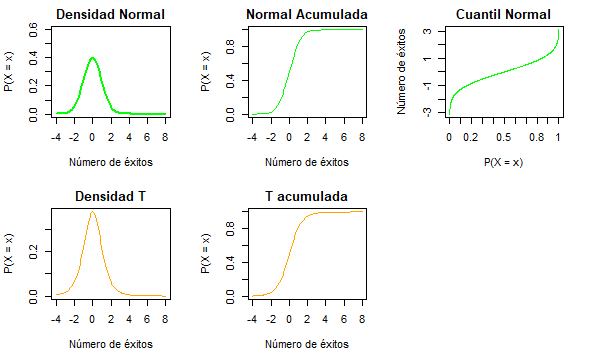

```r
plot(qt(seq(0, 1, 0.001),df = 5), type = 'l', xaxt = "n", col = "orange",
     main = 'Cuantil T', ylab = 'Número de éxitos', xlab = 'P(X = x)')
axis(1, labels = seq(0, 1, 0.1), at = 0:10 * 100)
```

[output not shown]

En las anteriores gráficas se logra observar la función de densidad, función acumulativa y función cuantil de 2 distribuciones continuas, siendo estas la **distribución normal y la distribución T-Student.** Para estas distribuciones se inicia estableciendo un margen de valores en el eje x **x <- seq(-4, 8, 0.1)** y un lienzo para un total de 6 gráficas **(par(mfrow = c(2, 3)))**, posterior a esto, se grafican la función de densidad, función acumulativa y la función cuantil de una distribución Normal con una **media de 0 y una desviación estandar de 1** mediante **dnorm(…), pnorm(…) y qnorm(…)** respectivamente, despues se grafican la función de densidad, función acumulativa y la función cuantil de una distribución T student con **5 grados de libertad** mediante **dt(…), pt(…) y qt(…)** respectivamente. Dichas funciones serán aplicadas dentro de la función **plot()**, la cual permite el dibujo de estas.

## 3. Investigando la construcción de los intervalos de confianza con el lenguaje de programación R

Se hace uso de la función read.table de R, para leer el dataframe abalone.data (siendo .data el tipo de archivo), usando como separador a la coma y cuyo nombre interno será data (contiene 4177 registros y 9 columnas).

```r
data=read.table("abalone.data",sep=",")
```

Se crea la función principal: **mu_ci(x,dist,n_samples,n_obs,ci)**, la cual recibe como parámetros un vector **x** (que en este contexto serán los valores de la columna “length” del dataframe abalone), el caracter **dist** cuyo valor puede ser ‘t’ o ‘n’ dependiendo de si se quiere muestrear siguiendo la distribucion t o la normal, **n_samples** hace referencia al número de muestras (que en este caso será siempre 10000), y **n_obs** almacena la cantidad de observaciones (que en este caso tomará valores de 20, 10 y 3), y **ci** se refiere al intervalo de confianza que se desea (0.9).

Internamente, en la función se halla la media poblacional **p_mean** del vector x, se inicializa un contador **cont** en cero. Se separa la obtención del valor donde las distribuciones tienen una probabilidad de 0.05 (ya que se quiere un intervalo de confianza **ci** de 0.9 y este valor es el alfa/2 con alfa=1-ci).

```r
mu_ci <- function(x,dist,n_samples,n_obs,ci){
  p_mean=mean(x);  cont=0; #Media poblacional y contador de intervalos que cumplen
  for (i in 1:n_samples){ #Itera hasta crear las n_samples muestras
    m=sample(x,n_obs) #Muestra con n_obs de observaciones
    m_mean=mean(m) #Media muestral
    m_sd=sd(m) #Desviacion estándar muestral
    if (dist=='n'){
      q=qnorm((1-ci)/2,lower.tail=0)} #Valor donde la prob. es 0.05 en la dist. normal
    if(dist=='t'){
      q=qt((1-ci)/2,df=n_obs-1,lower.tail=0)} #Valor donde la prob. es 0.05 en la dist. t
    l_lim=m_mean-(q*(m_sd/sqrt(n_obs))) #Limite inferior del intervalo de confianza
    u_lim=m_mean+(q*(m_sd/sqrt(n_obs))) #Limite superior del intervalo de confianza
    if (p_mean>=l_lim && p_mean<=u_lim)
      {cont=cont+1}} #Conteo de casos donde la media poblacional está dentro del I. de C.
  return(cont/n_samples) #Retorno de la fraccion a analizar
}
```

En los siguientes casos se pasará como argumento el vector data$V2, que es la segunda colummna del dataframe abalone.data y contiene los valores de “length” que se quieren estudiar, así como se usará la función creada **mu_ci(x,dist,n_samples,n_obs,ci)**.

```r
a=mu_ci(data$V2,'t',10000,20,0.9); a
```

```
[1] 0.8977
```

[output not shown]

```r
b=mu_ci(data$V2,'t',10000,10,0.9); b
```

```
[1] 0.8957
```

[output not shown]

```r
c=mu_ci(data$V2,'n',10000,10,0.9); c
```

```
[1] 0.8589
```

[output not shown]

```r
d=mu_ci(data$V2,'t',10000,3,0.9); d
```

```
[1] 0.873
```

[output not shown]

```r
e=mu_ci(data$V2,'n',10000,3,0.9); e
```

```
[1] 0.7477
```

[output not shown]